# regression

## Questions I had before/during reading:

1. What is the difference between correlation and linear regression? when should you use one vs the other?
   - pearson correlation is equivalent to a linear regression with 1 predictor
   - linear regression can have multiple predictors
2. Is mean centering the same as standardizing coefficients? when should you do either?
- standardizing - subtracting the mean of the variable and dividing by sd. helps with the interpretation of the estimated coefficients
- centering - just subtracting the mean. helps with the interpretation of the estimated constant
3. what are people’s opinions of $R^{2}$ vs adjusted $R^{2}$?
- $R^{2}$ is more interpretable whereas adjusted accounts for bias
- In her book, Dani says she prefers $R^{2}$
4. Are some assumptions more important than others? do people actually check the assumptions?
- assumptions: linearity, homoscedasticity (variance of residuals is the same for any value of x), independence (observations are independent of each other), normality
- SXL: Re: whether people do check assumptions, I’m sure some do but I don’t remember seeing it reported very often!
- ??
5. What does is mean to say “residuals that are independent of each other”?
- SXL: I think this means that the residuals can be treated as independent samples (i.e., the probability of getting one value should not affect the probability of getting another)…?
- ??
6. What are the different types of residuals?
- regular vs standardised vs studentised
- ??
7. What is an ideal workflow for checking your model and all the assumptions?
- go through example below
8. What to do when specific assumptions are violated?
- if data is non-linear, can try a transformation and check residual vs predicted/fitted values to see if that helped
  - what are some common transformations? $var^{2}$ or log()
- if collinearity, drop one of the problematic variables or combine variables into a single predictor
- [datasets in R](https://machinelearningmastery.com/machine-learning-datasets-in-r/)

```r
library(tidyverse)
library(janitor)
library(car)
library(mlbench)
library(broom)

theme_set(theme_bw())
```

## simple linear regression

- Boston Housing dataset
- first, let’s look at relationships between different variables

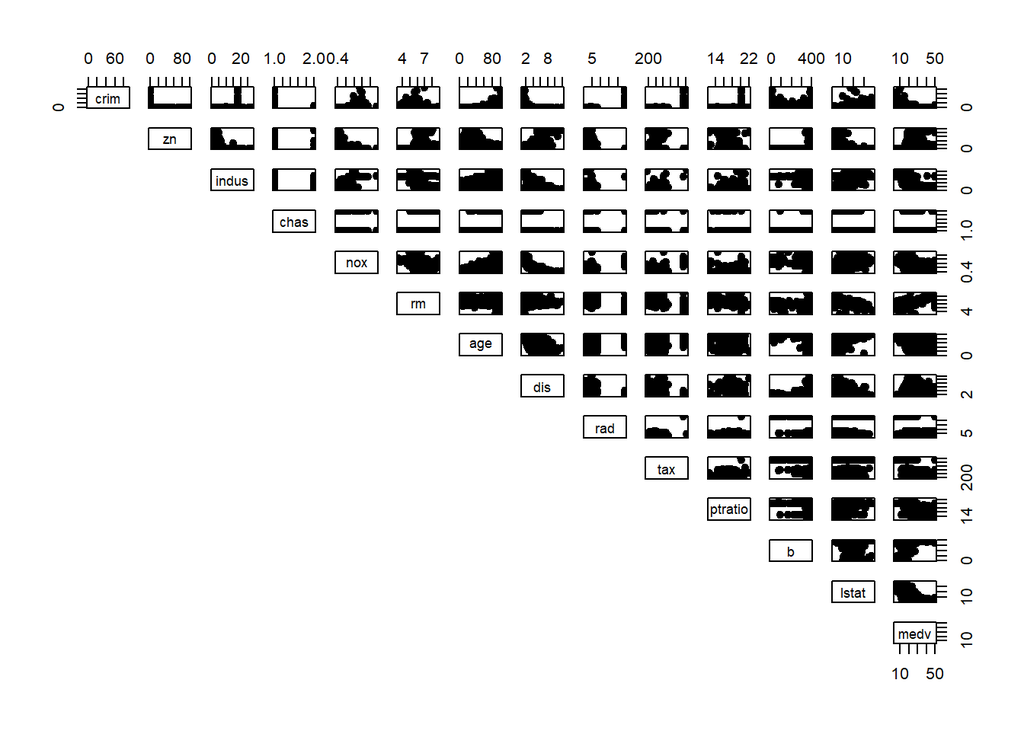

```r
data(BostonHousing)
# ?BostonHousing

boston <- BostonHousing %>%
  as_tibble()

pairs(boston, pch=19, lower.panel = NULL)
```

- pretty clear relationship between rm (avg number of rooms per dwelling) and medv (median value of owner-occupied homes)
- dis (distance to 5 employment centers) and nox (nitric oxides concentration) perhaps quadratic relationship??
  - this seems more interesting so let’s look at this
  - also good exercise because a lot of times our data won’t be linear
- monotonically decreasing. exponential probably better than quadratric

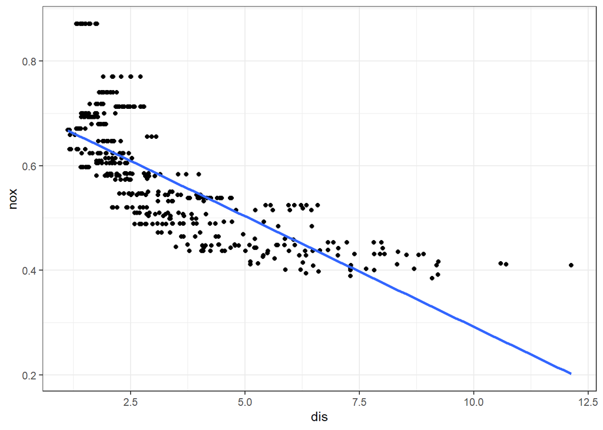

```r
ggplot(boston, aes(dis, nox)) +
  geom_point() +
  geom_smooth(method = "lm", se = FALSE) # not surprising, but not a very good fit
```

```r
m1 <- lm(nox ~ dis, data=boston)
m1
```

```
##
## Call:
## lm(formula = nox ~ dis, data = boston)
##
## Coefficients:
## (Intercept)          dis
##     0.71534     -0.04233
```

```r
summary(m1)
```

```
##
## Call:
## lm(formula = nox ~ dis, data = boston)
##
## Residuals:
##      Min       1Q   Median       3Q      Max
## -0.12239 -0.05212 -0.01257  0.04391  0.23041
##
## Coefficients:
##              Estimate Std. Error t value Pr(>|t|)
## (Intercept)  0.715343   0.006796  105.26   <2e-16 ***
## dis         -0.042331   0.001566  -27.03   <2e-16 ***
## ---
## Signif. codes:  0 '***' 0.001 '**' 0.01 '*' 0.05 '.' 0.1 ' ' 1
##
## Residual standard error: 0.07412 on 504 degrees of freedom
## Multiple R-squared:  0.5917, Adjusted R-squared:  0.5909
## F-statistic: 730.4 on 1 and 504 DF,  p-value: < 2.2e-16
```

```r
tidy(m1)
```

```
## # A tibble: 2 x 5
##   term        estimate std.error statistic   p.value
##   <chr>          <dbl>     <dbl>     <dbl>     <dbl>
## 1 (Intercept)   0.715    0.00680     105.  0
## 2 dis          -0.0423   0.00157     -27.0 4.23e-100
```

```r
glance(m1)
```

```
## # A tibble: 1 x 12
##   r.squared adj.r.squared  sigma statistic   p.value    df logLik    AIC    BIC
##       <dbl>         <dbl>  <dbl>     <dbl>     <dbl> <dbl>  <dbl>  <dbl>  <dbl>
## 1     0.592         0.591 0.0741      730. 4.23e-100     1   600. -1193. -1181.
## # ... with 3 more variables: deviance <dbl>, df.residual <int>, nobs <int>
```

```r
names(m1)
```

```
##  [1] "coefficients"  "residuals"     "effects"       "rank"
##  [5] "fitted.values" "assign"        "qr"            "df.residual"
##  [9] "xlevels"       "call"          "terms"         "model"
```

```r
m1$coefficients # or coef(m1)
```

```
## (Intercept)         dis
##   0.7153426  -0.0423309
```

```r
predict(m1, data.frame(dis=c(6)),
        interval="confidence")
```

```
##         fit       lwr      upr
## 1 0.4613572 0.4519795 0.470735
```

- predict function
- y = mx + c
- using our model:
  - y = -0.042*6 + 0.715
  - y = 0.463
- predict() returns 0.461

## check assumptions: what to look for in each?

*Most of these notes including the outliers images are taken from Danielle’s book Chapter 15*

### 1. normality - assume residuals are normally distributed

- can plot histogram to see distribution
- can do a Shapiro-Wilk test to check
- can check the QQ plot

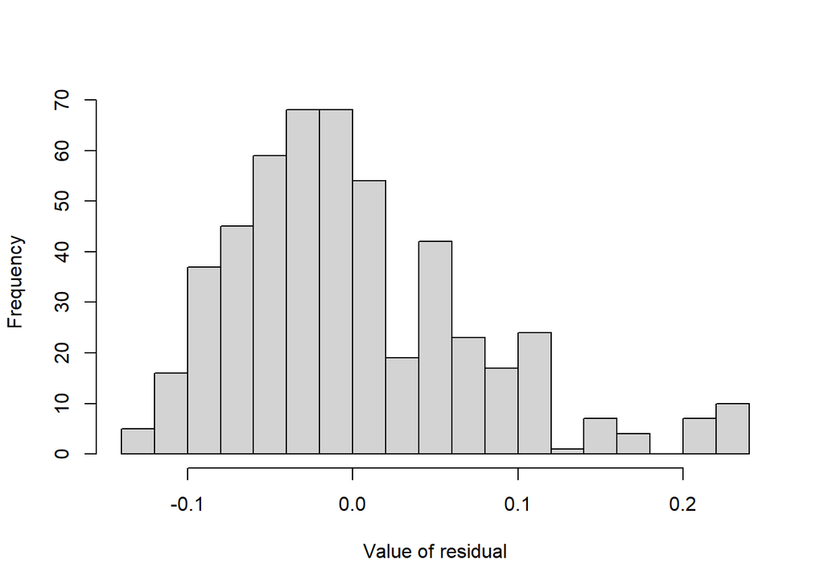

```r
hist(x = residuals(m1),
     xlab = "Value of residual",
     main = "",
     breaks = 20)
```

```r
shapiro.test(residuals(m1)) # here we see a significant result, so may be reason to be concerned
```

```
##
##  Shapiro-Wilk normality test
##
## data:  residuals(m1)
## W = 0.93616, p-value = 6.691e-14
```

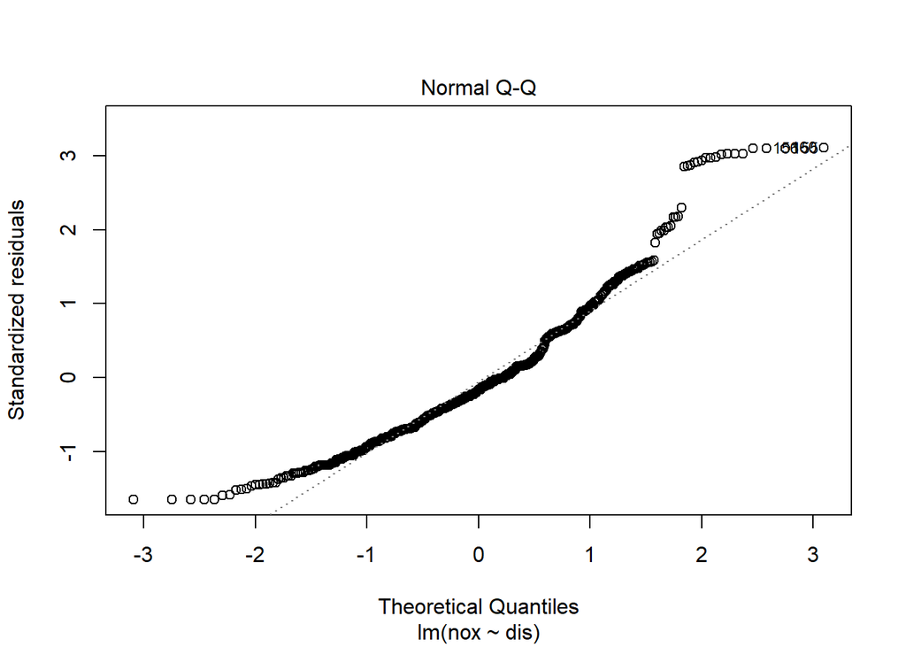

```r
plot(m1, which = 2)
```

### 2. linearity

- can plot fitted values against the observed values
- can plot fitted values against the residuals `plot(model, which=1)` - want to see a straight, horizontal line
  - `car::residualPlots()` creates a similar plot but for each predictor

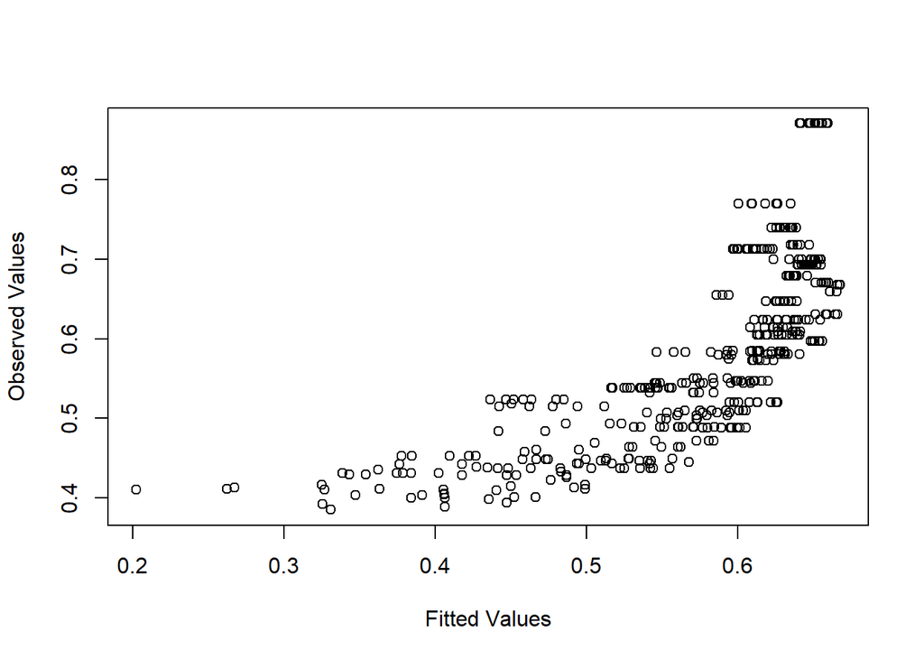

```r
fit_vals <- fitted.values(m1)

# want this to look linear
plot(x = fit_vals, y = boston$nox, xlab = "Fitted Values", ylab = "Observed Values") # ...not great
```

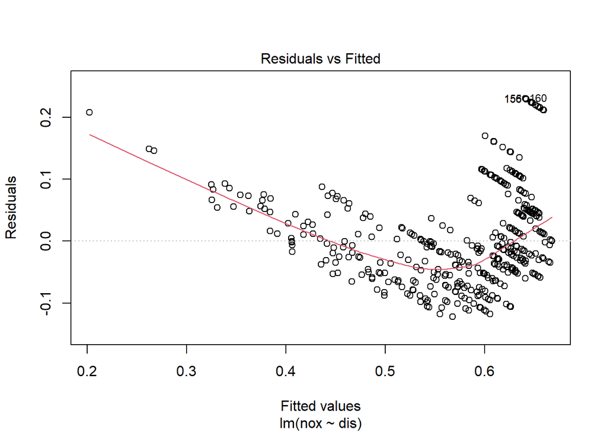

```r
plot(m1, which=1)
```

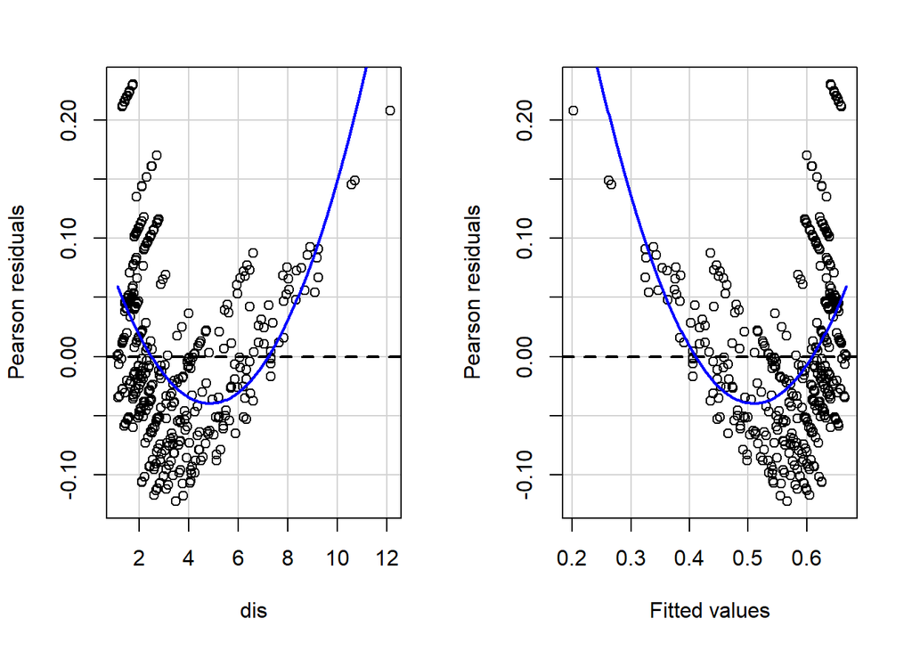

```
##            Test stat Pr(>|Test stat|)
## dis           13.462        < 2.2e-16 ***
## Tukey test    13.462        < 2.2e-16 ***
## ---
## Signif. codes:  0 '***' 0.001 '**' 0.01 '*' 0.05 '.' 0.1 ' ' 1
```

```r
residualPlots(m1) # Tukey test comes out significant, suggesting (clear) curvature
```

### 3. homogeneity of variance - variance of the residuals is assumed to be constant

- `plot(model, which=3)` - want to see straight, horizontal line through the middle of the plot
- `car::ncvTest()` non-constant variance test: looks at the relationship between the fitted values and the variance of the residuals
- note: if this assumption is violated, the se estimates associated with the regression coefficients are not entirely reliable

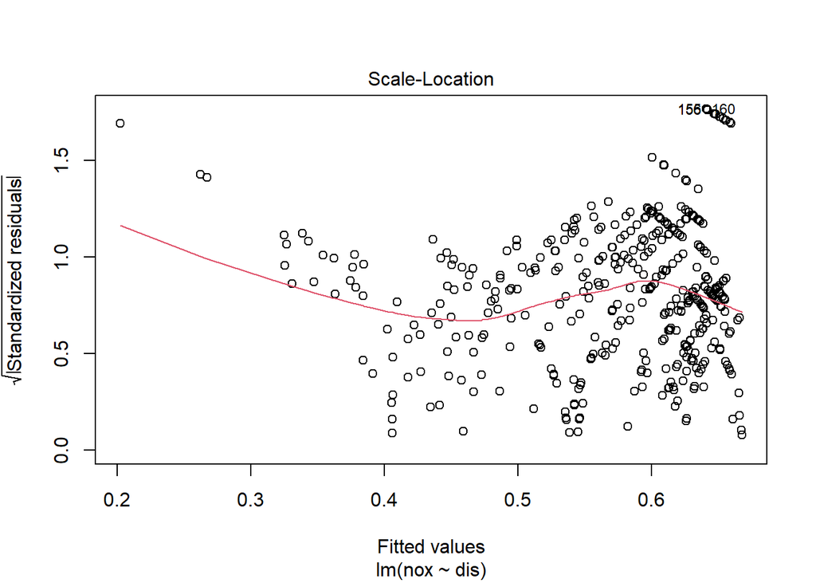

```r
plot(m1, which=3)
```

```r
ncvTest(m1) # and we see that we have violated yet another assumption
```

```
## Non-constant Variance Score Test
## Variance formula: ~ fitted.values
## Chisquare = 14.5774, Df = 1, p = 0.00013452
```

### 4. uncorrelated predictors

- variance inflation factors (VIFs) can help us determine if predictors in the model are too highly correlated with each other
  - high numbers are a sign that there is collinearity *not sure I understand what’s going on here..*

```r
# we'll create a second model that has 2 predictors

m2 <- lm(nox ~ dis + zn, data=boston)
vif(m2)
```

```
##      dis       zn
## 1.790312 1.790312
```

```r
m2_interaction <- lm(nox ~ dis * zn, data=boston)
vif(m2_interaction)
```

```
##       dis        zn    dis:zn
##  2.130589 12.535550 14.626424
```

### 5. residuals are independent of each other

### 6. no “bad” outliers

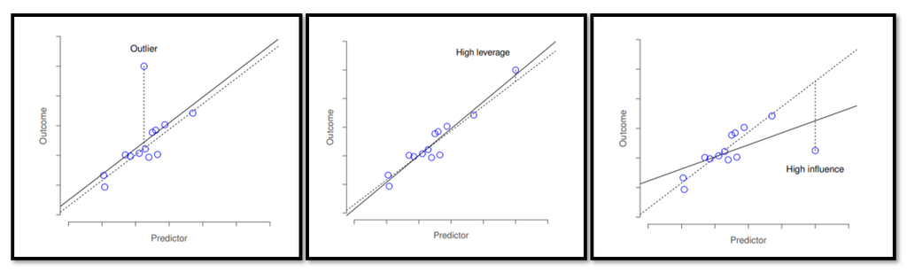

## multiple linear regression

```r
m2 <- lm(dis ~ ., data=boston) # all predictors
summary(m2)
```

```
##
## Call:
## lm(formula = dis ~ ., data = boston)
##
## Residuals:
##     Min      1Q  Median      3Q     Max
## -2.5462 -0.6364 -0.0463  0.5347  4.3103
##
## Coefficients:
##               Estimate Std. Error t value Pr(>|t|)
## (Intercept) 10.6670771  1.0442339  10.215  < 2e-16 ***
## crim        -0.0246488  0.0070367  -3.503 0.000502 ***
## zn           0.0280890  0.0026948  10.424  < 2e-16 ***
## indus       -0.0571758  0.0129331  -4.421 1.21e-05 ***
## chas1        0.1209801  0.1864785   0.649 0.516795
## nox         -6.0641064  0.7909332  -7.667 9.48e-14 ***
## rm           0.0066286  0.0968849   0.068 0.945481
## age         -0.0173148  0.0027228  -6.359 4.64e-10 ***
## rad          0.0160172  0.0145126   1.104 0.270271
## tax         -0.0005065  0.0008148  -0.622 0.534469
## ptratio     -0.0093794  0.0295223  -0.318 0.750843
## b            0.0003656  0.0005827   0.627 0.530708
## lstat       -0.0268033  0.0119385  -2.245 0.025203 *
## medv        -0.0678417  0.0091703  -7.398 6.01e-13 ***
## ---
## Signif. codes:  0 '***' 0.001 '**' 0.01 '*' 0.05 '.' 0.1 ' ' 1
##
## Residual standard error: 1.017 on 492 degrees of freedom
## Multiple R-squared:  0.7725, Adjusted R-squared:  0.7665
## F-statistic: 128.5 on 13 and 492 DF,  p-value: < 2.2e-16
```

```r
summary(m2)$r.sq
```

```
## [1] 0.7725208
```

```r
vif(m2) # help determine if predictors are too highly correlated
```

```
##     crim       zn    indus     chas      nox       rm      age      rad
## 1.786970 1.926702 3.839965 1.094287 4.097373 2.260353 2.865329 7.788914
##      tax  ptratio        b    lstat     medv
## 9.198317 1.992607 1.380359 3.545263 3.469711
```

```r
# some numbers are large what to do next? try to remove collinearity?

m3 <- lm(dis ~ . - tax - lstat, data=boston) # not sure which variables to remove? systematic way to do this?
vif(m3)
```

```
##     crim       zn    indus     chas      nox       rm      age      rad
## 1.769469 1.797469 3.047264 1.083398 4.085214 2.070784 2.507182 2.868792
##  ptratio        b     medv
## 1.973707 1.372211 2.828721
```

## non linear transformation

- when transforming predictors so it’s ^2, you need to wrap it in `I()` because ^ has a special meaning in a formula
- the fact that the transformed predictor (quadratic term) is significant, near 0, suggests it leads to an improved model
- can do anova() to quantify the extent to which the quadratic fit is superior to the linear fit
- can use the poly() to test multiple polynomial terms at once

```r
m4 = lm(dis ~ nox + nox^2, data=boston)
summary(m4)
```

```
##
## Call:
## lm(formula = dis ~ nox + nox^2, data = boston)
##
## Residuals:
##     Min      1Q  Median      3Q     Max
## -2.1731 -1.0339 -0.2507  0.7672  6.3089
##
## Coefficients:
##             Estimate Std. Error t value Pr(>|t|)
## (Intercept)  11.5487     0.2931   39.41   <2e-16 ***
## nox         -13.9783     0.5172  -27.03   <2e-16 ***
## ---
## Signif. codes:  0 '***' 0.001 '**' 0.01 '*' 0.05 '.' 0.1 ' ' 1
##
## Residual standard error: 1.347 on 504 degrees of freedom
## Multiple R-squared:  0.5917, Adjusted R-squared:  0.5909
## F-statistic: 730.4 on 1 and 504 DF,  p-value: < 2.2e-16
```

```r
m5 = lm(dis ~ nox + I(nox^2), data=boston)
summary(m5)
```

```
##
## Call:
## lm(formula = dis ~ nox + I(nox^2), data = boston)
##
## Residuals:
##     Min      1Q  Median      3Q     Max
## -2.2298 -0.7270 -0.0714  0.5761  5.3147
##
## Coefficients:
##             Estimate Std. Error t value Pr(>|t|)
## (Intercept)   28.743      1.065   26.99   <2e-16 ***
## nox          -74.167      3.659  -20.27   <2e-16 ***
## I(nox^2)      50.428      3.046   16.56   <2e-16 ***
## ---
## Signif. codes:  0 '***' 0.001 '**' 0.01 '*' 0.05 '.' 0.1 ' ' 1
##
## Residual standard error: 1.085 on 503 degrees of freedom
## Multiple R-squared:  0.7357, Adjusted R-squared:  0.7347
## F-statistic: 700.1 on 2 and 503 DF,  p-value: < 2.2e-16
```

```r
anova(m1, m5)
```

```
## Analysis of Variance Table
##
## Response: nox
##            Df Sum Sq Mean Sq F value    Pr(>F)
## dis         1 4.0124  4.0124  730.43 < 2.2e-16 ***
## Residuals 504 2.7686  0.0055
## ---
## Signif. codes:  0 '***' 0.001 '**' 0.01 '*' 0.05 '.' 0.1 ' ' 1
```

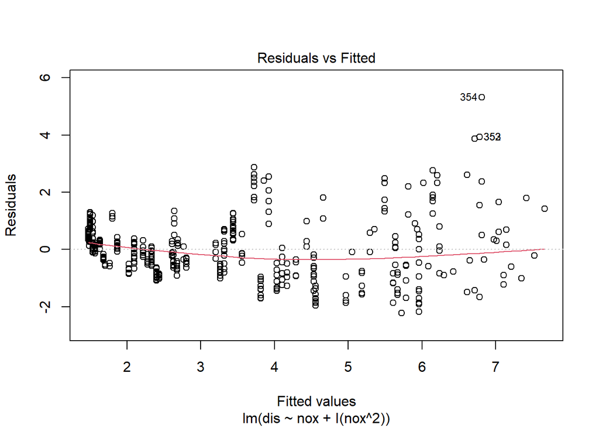

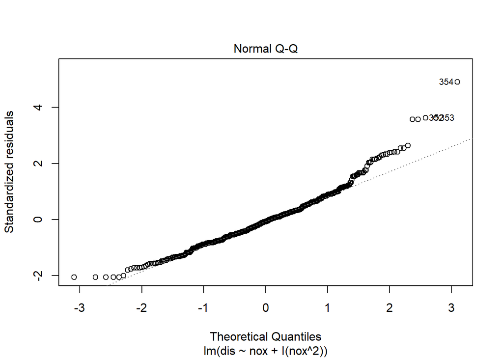

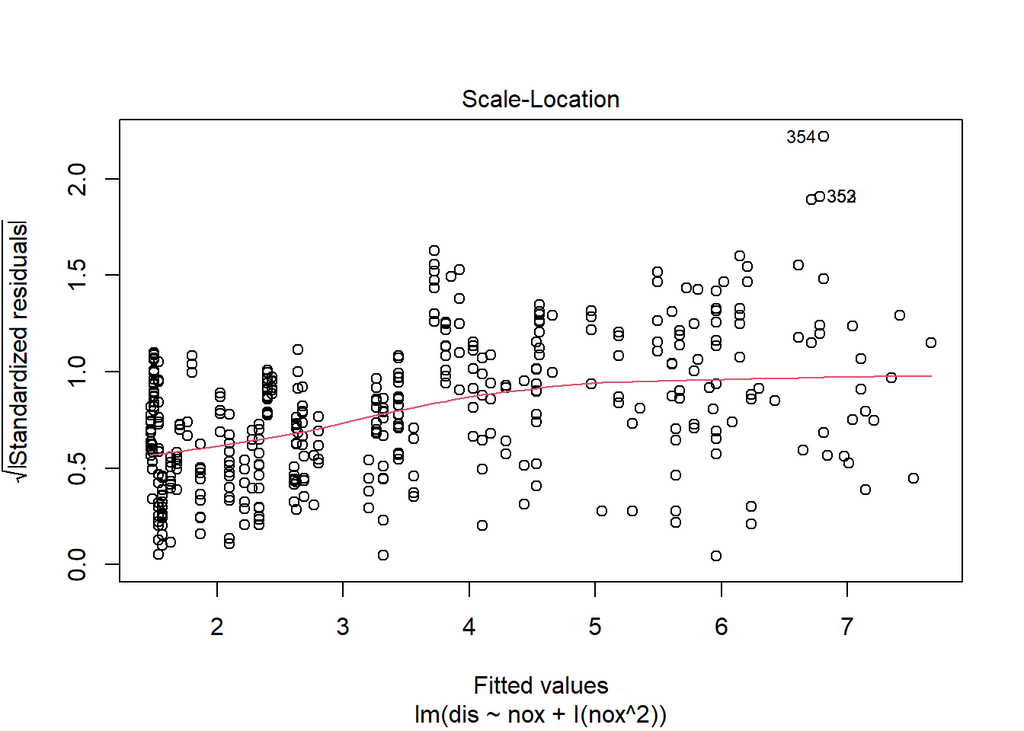

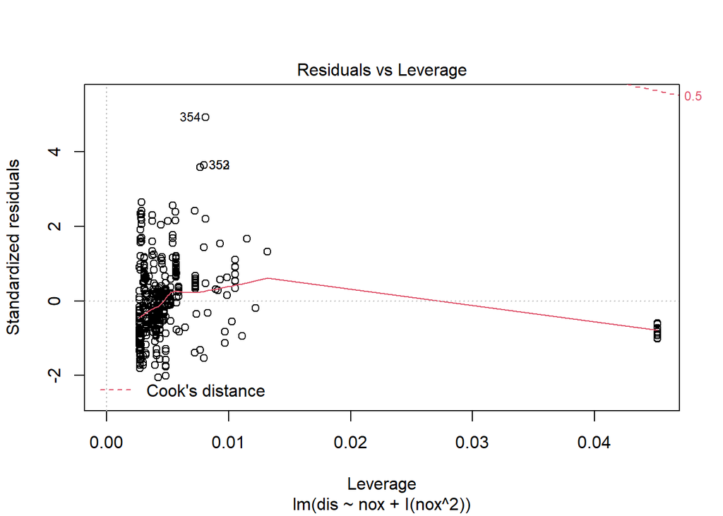

```r
plot(m5)
```

```r
# what about ^3? or ^4
m6 = lm(dis ~ poly(nox,5), data=boston)
summary(m6)
```

```
##
## Call:
## lm(formula = dis ~ poly(nox, 5), data = boston)
##
## Residuals:
##     Min      1Q  Median      3Q     Max
## -2.0881 -0.5920 -0.1139  0.4328  4.9772
##
## Coefficients:
##                Estimate Std. Error t value Pr(>|t|)
## (Intercept)     3.79504    0.04631  81.944  < 2e-16 ***
## poly(nox, 5)1 -36.39993    1.04177 -34.940  < 2e-16 ***
## poly(nox, 5)2  17.95702    1.04177  17.237  < 2e-16 ***
## poly(nox, 5)3  -6.14793    1.04177  -5.901 6.65e-09 ***
## poly(nox, 5)4  -0.87277    1.04177  -0.838  0.40256
## poly(nox, 5)5  -3.25017    1.04177  -3.120  0.00191 **
## ---
## Signif. codes:  0 '***' 0.001 '**' 0.01 '*' 0.05 '.' 0.1 ' ' 1
##
## Residual standard error: 1.042 on 500 degrees of freedom
## Multiple R-squared:  0.7577, Adjusted R-squared:  0.7552
## F-statistic: 312.6 on 5 and 500 DF,  p-value: < 2.2e-16
```